# Projekt1

Tomasz Solarski

4 01 2022

# Część 1 - Zadania z ćwiczeń projektowych.

## Ćw.1, Zadanie 9

Stworzyć zmienną książki mówiącą o tym, ile dana osoba przeczytała książek w ostatnim kwartale.

```r
ksiazki <- sample(0:4, size = 25, replace = TRUE)
ksiazki
```

```
##  [1] 3 3 4 1 4 4 0 3 0 0 3 3 2 4 0 3 1 3 4 0 1 2 1 2 2
```

Ile wynosi średnia liczby przeczytanych książek?

```r
mean(ksiazki)
```

```
## [1] 2.12
```

Ile osób przeczytało przynajmniej trzy książki?

```r
sum(ksiazki>=3)
```

```
## [1] 12
```

Ile osób nie przeczytało żadnej książki?

```r
sum(ksiazki==0)
```

```
## [1] 5
```

Stworzyć zmienną ksiazki2, która będzie mówiła o tym, czy ktoś czyta książki (przeczytał min. jedna). Uzyj do tego petli for.

```r
ksiazki2 <- c()
for(element in ksiazki){
  ksiazki2 <- c(ksiazki2, ifelse(element>=1, "czytajacy", "nieczytajacy"))
}
ksiazki
```

```
##  [1] 3 3 4 1 4 4 0 3 0 0 3 3 2 4 0 3 1 3 4 0 1 2 1 2 2
```

```r
ksiazki2
```

```
##  [1] "czytajacy"    "czytajacy"    "czytajacy"    "czytajacy"    "czytajacy"
##  [6] "czytajacy"    "nieczytajacy" "czytajacy"    "nieczytajacy" "nieczytajacy"
## [11] "czytajacy"    "czytajacy"    "czytajacy"    "czytajacy"    "nieczytajacy"
## [16] "czytajacy"    "czytajacy"    "czytajacy"    "czytajacy"    "nieczytajacy"
## [21] "czytajacy"    "czytajacy"    "czytajacy"    "czytajacy"    "czytajacy"
```

Stworzyć instrukcję warunkową, która mając datę (miesiąc i rok), odpowie na pytanie o liczbę dni w tym miesiącu.

```r
ileDni <- function(miesiac, rok){
if(miesiac == 2){
  if(rok%%4==0 && rok%%100!=0){
    print(29)
  }
  else if(rok%%400==0){
      print(29)
    }
  else{
      print(28)
    }
  }
 else if(miesiac %in% c(1,3,5,7,8,10,12)){
  print(31)
} else{
  print(30)
}
}
ileDni(2,1900)
```

```
## [1] 28
```

```r
ileDni(3,1900)
```

```
## [1] 31
```

```r
ileDni(2,2020)
```

```
## [1] 29
```

```r
ileDni(2,2100)
```

```
## [1] 28
```

## Ćw.1, Zadanie 2,3

```r
osoby <- data.frame(wzrost = c(180,170,184,165,161,185,184),
                    waga = c(80,70,76,67,80,71,65))
osoby
```

```
##   wzrost waga
## 1    180   80
## 2    170   70
## 3    184   76
## 4    165   67
## 5    161   80
## 6    185   71
## 7    184   65
```

```r
str(osoby)
```

```
## 'data.frame':    7 obs. of  2 variables:
##  $ wzrost: num  180 170 184 165 161 185 184
##  $ waga  : num  80 70 76 67 80 71 65
```

```r
head(osoby,3)
```

```
##   wzrost waga
## 1    180   80
## 2    170   70
## 3    184   76
```

```r
tail(osoby,5)
```

```
##   wzrost waga
## 3    184   76
## 4    165   67
## 5    161   80
## 6    185   71
## 7    184   65
```

```r
dim(osoby)
```

```
## [1] 7 2
```

```r
summary(osoby)
```

```
##      wzrost           waga
##  Min.   :161.0   Min.   :65.00
##  1st Qu.:167.5   1st Qu.:68.50
##  Median :180.0   Median :71.00
##  Mean   :175.6   Mean   :72.71
##  3rd Qu.:184.0   3rd Qu.:78.00
##  Max.   :185.0   Max.   :80.00
```

Wykorzystać funkcję rownames() do nadania imion obiektom w ramce osoby.

```r
row.names(osoby) <-  c("Tomek", "Janek", "Kuba", "Sebastian", "Marcin", "Zygmunt", "Stach")
osoby
```

```
##           wzrost waga
## Tomek        180   80
## Janek        170   70
## Kuba         184   76
## Sebastian    165   67
## Marcin       161   80
## Zygmunt      185   71
## Stach        184   65
```

Stworzyć obiekt BMI, który bedzie przechowywał informacje o wartościach BMI (ang. body mass index)

```r
osoby$BMI <- osoby$waga/(osoby$wzrost/100)^2
osoby
```

```
##           wzrost waga      BMI
## Tomek        180   80 24.69136
## Janek        170   70 24.22145
## Kuba         184   76 22.44802
## Sebastian    165   67 24.60973
## Marcin       161   80 30.86301
## Zygmunt      185   71 20.74507
## Stach        184   65 19.19896
```

Wyświetl tylko te osoby, których BMI przyjmuje wartość wiekszą niż 30.

```r
osoby[osoby$BMI>30,]
```

```
##        wzrost waga      BMI
## Marcin    161   80 30.86301
```

Ile jest osób o BMI≤25?

```r
sum((osoby$BMI<=25)==T)
```

```
## [1] 6
```

## Ćw.1, Zadanie 5

W pakiecie psych istnieje funkcja describe(). Postaraj się, za jej pomocą, wyswietlić statytyski opisowe dla danych mtcars. Czym się ona różni od funkcji summary()?

```r
describe(mtcars)
```

```
##      vars  n   mean     sd median trimmed    mad   min    max  range  skew
## mpg     1 32  20.09   6.03  19.20   19.70   5.41 10.40  33.90  23.50  0.61
## cyl     2 32   6.19   1.79   6.00    6.23   2.97  4.00   8.00   4.00 -0.17
## disp    3 32 230.72 123.94 196.30  222.52 140.48 71.10 472.00 400.90  0.38
## hp      4 32 146.69  68.56 123.00  141.19  77.10 52.00 335.00 283.00  0.73
## drat    5 32   3.60   0.53   3.70    3.58   0.70  2.76   4.93   2.17  0.27
## wt      6 32   3.22   0.98   3.33    3.15   0.77  1.51   5.42   3.91  0.42
## qsec    7 32  17.85   1.79  17.71   17.83   1.42 14.50  22.90   8.40  0.37
## vs      8 32   0.44   0.50   0.00    0.42   0.00  0.00   1.00   1.00  0.24
## am      9 32   0.41   0.50   0.00    0.38   0.00  0.00   1.00   1.00  0.36
## gear   10 32   3.69   0.74   4.00    3.62   1.48  3.00   5.00   2.00  0.53
## carb   11 32   2.81   1.62   2.00    2.65   1.48  1.00   8.00   7.00  1.05
##      kurtosis    se
## mpg     -0.37  1.07
## cyl     -1.76  0.32
## disp    -1.21 21.91
## hp      -0.14 12.12
## drat    -0.71  0.09
## wt      -0.02  0.17
## qsec     0.34  0.32
## vs      -2.00  0.09
## am      -1.92  0.09
## gear    -1.07  0.13
## carb     1.26  0.29
```

```r
summary(mtcars)
```

```
##       mpg             cyl             disp             hp
##  Min.   :10.40   Min.   :4.000   Min.   : 71.1   Min.   : 52.0
##  1st Qu.:15.43   1st Qu.:4.000   1st Qu.:120.8   1st Qu.: 96.5
##  Median :19.20   Median :6.000   Median :196.3   Median :123.0
##  Mean   :20.09   Mean   :6.188   Mean   :230.7   Mean   :146.7
##  3rd Qu.:22.80   3rd Qu.:8.000   3rd Qu.:326.0   3rd Qu.:180.0
##  Max.   :33.90   Max.   :8.000   Max.   :472.0   Max.   :335.0
##       drat             wt             qsec             vs
##  Min.   :2.760   Min.   :1.513   Min.   :14.50   Min.   :0.0000
##  1st Qu.:3.080   1st Qu.:2.581   1st Qu.:16.89   1st Qu.:0.0000
##  Median :3.695   Median :3.325   Median :17.71   Median :0.0000
##  Mean   :3.597   Mean   :3.217   Mean   :17.85   Mean   :0.4375
##  3rd Qu.:3.920   3rd Qu.:3.610   3rd Qu.:18.90   3rd Qu.:1.0000
##  Max.   :4.930   Max.   :5.424   Max.   :22.90   Max.   :1.0000
##        am              gear            carb
##  Min.   :0.0000   Min.   :3.000   Min.   :1.000
##  1st Qu.:0.0000   1st Qu.:3.000   1st Qu.:2.000
##  Median :0.0000   Median :4.000   Median :2.000
##  Mean   :0.4062   Mean   :3.688   Mean   :2.812
##  3rd Qu.:1.0000   3rd Qu.:4.000   3rd Qu.:4.000
##  Max.   :1.0000   Max.   :5.000   Max.   :8.000
```

```r
class(describe(mtcars))
```

```
## [1] "psych"      "describe"   "data.frame"
```

```r
class(summary(mtcars))
```

```
## [1] "table"
```

Obie komendy pokazują bardzo podobne informacje. Funkcja describe() nie pokazuje kwartyli, ale pokazuje odchylenie standardowe, zakres oraz inne dodatkowe parametry. Desribe() jest w formie data.frame a summary() w formie table.

Poznaj i zaproponuj sensowne wykorzystanie funkcji describeBy()

```r
describeBy(mtcars, mtcars$cyl)
```

```
##
##  Descriptive statistics by group
## group: 4
##      vars  n   mean    sd median trimmed   mad   min    max range  skew
## mpg     1 11  26.66  4.51  26.00   26.44  6.52 21.40  33.90 12.50  0.26
## cyl     2 11   4.00  0.00   4.00    4.00  0.00  4.00   4.00  0.00   NaN
## disp    3 11 105.14 26.87 108.00  104.30 43.00 71.10 146.70 75.60  0.12
## hp      4 11  82.64 20.93  91.00   82.67 32.62 52.00 113.00 61.00  0.01
## drat    5 11   4.07  0.37   4.08    4.02  0.34  3.69   4.93  1.24  1.00
## wt      6 11   2.29  0.57   2.20    2.27  0.54  1.51   3.19  1.68  0.30
## qsec    7 11  19.14  1.68  18.90   18.99  1.48 16.70  22.90  6.20  0.55
## vs      8 11   0.91  0.30   1.00    1.00  0.00  0.00   1.00  1.00 -2.47
## am      9 11   0.73  0.47   1.00    0.78  0.00  0.00   1.00  1.00 -0.88
## gear   10 11   4.09  0.54   4.00    4.11  0.00  3.00   5.00  2.00  0.11
## carb   11 11   1.55  0.52   2.00    1.56  0.00  1.00   2.00  1.00 -0.16
##      kurtosis   se
## mpg     -1.65 1.36
## cyl       NaN 0.00
## disp    -1.64 8.10
## hp      -1.71 6.31
## drat     0.12 0.11
## wt      -1.36 0.17
## qsec    -0.02 0.51
## vs       4.52 0.09
## am      -1.31 0.14
## gear    -0.01 0.16
## carb    -2.15 0.16
## ------------------------------------------------------------
## group: 6
##      vars n   mean    sd median trimmed   mad    min    max  range  skew
## mpg     1 7  19.74  1.45  19.70   19.74  1.93  17.80  21.40   3.60 -0.16
## cyl     2 7   6.00  0.00   6.00    6.00  0.00   6.00   6.00   0.00   NaN
## disp    3 7 183.31 41.56 167.60  183.31 11.27 145.00 258.00 113.00  0.80
## hp      4 7 122.29 24.26 110.00  122.29  7.41 105.00 175.00  70.00  1.36
## drat    5 7   3.59  0.48   3.90    3.59  0.03   2.76   3.92   1.16 -0.74
## wt      6 7   3.12  0.36   3.21    3.12  0.36   2.62   3.46   0.84 -0.22
## qsec    7 7  17.98  1.71  18.30   17.98  1.90  15.50  20.22   4.72 -0.12
## vs      8 7   0.57  0.53   1.00    0.57  0.00   0.00   1.00   1.00 -0.23
## am      9 7   0.43  0.53   0.00    0.43  0.00   0.00   1.00   1.00  0.23
## gear   10 7   3.86  0.69   4.00    3.86  0.00   3.00   5.00   2.00  0.11
```

[output cut: 24 more lines]

```
## am      9 14   0.14  0.36   0.00    0.08  0.00   0.00   1.00   1.00  1.83
## gear   10 14   3.29  0.73   3.00    3.17  0.00   3.00   5.00   2.00  1.83
## carb   11 14   3.50  1.56   3.50    3.25  0.74   2.00   8.00   6.00  1.48
##      kurtosis    se
## mpg     -0.57  0.68
## cyl       NaN  0.00
## disp    -1.26 18.11
## hp       0.09 13.62
## drat     1.08  0.10
## wt      -0.71  0.20
## qsec    -0.92  0.32
## vs        NaN  0.00
## am       1.45  0.10
## gear     1.45  0.19
## carb     2.24  0.42
```

## Ćw.2, Zadanie 10 na dwa sposoby

Na jednym wykresie liniowym narysować, jak w rozważanych latach zmieniała się oczekiwana długość życia w trzech wybranych przez Ciebie krajach.

1 sposób:

```r
dane <- gapminder %>%
  filter(country %in% c("Poland", "China", "Canada")) %>%
  select(country, lifeExp, year) %>%
  spread(country, lifeExp)
dane
```

```
## # A tibble: 12 x 4
##     year Canada China Poland
##    <int>  <dbl> <dbl>  <dbl>
##  1  1952   68.8  44     61.3
##  2  1957   70.0  50.5   65.8
##  3  1962   71.3  44.5   67.6
##  4  1967   72.1  58.4   69.6
##  5  1972   72.9  63.1   70.8
##  6  1977   74.2  64.0   70.7
##  7  1982   75.8  65.5   71.3
##  8  1987   76.9  67.3   71.0
##  9  1992   78.0  68.7   71.0
## 10  1997   78.6  70.4   72.8
## 11  2002   79.8  72.0   74.7
## 12  2007   80.7  73.0   75.6
```

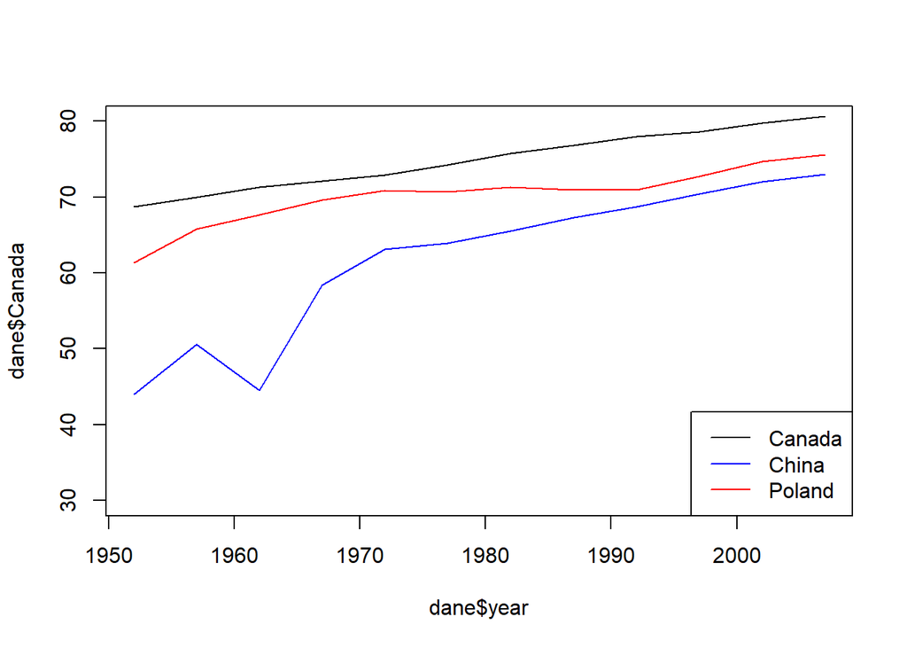

```r
plot(dane$year, dane$Canada, type = "l", ylim = c(30,80))
lines(dane$year, dane$China, type = "l", col ="blue")
lines(dane$year, dane$Poland, type = "l", col ="red")
legend("bottomright",c("Canada", "China", "Poland"),lty = 1, col = c("black", "blue", "red"))
```

2 sposób:

```r
library(reshape2)
dane_long <- melt(dane, id.vars = "year")
dane_long
```

```
##    year variable    value
## 1  1952   Canada 68.75000
## 2  1957   Canada 69.96000
## 3  1962   Canada 71.30000
## 4  1967   Canada 72.13000
## 5  1972   Canada 72.88000
## 6  1977   Canada 74.21000
## 7  1982   Canada 75.76000
## 8  1987   Canada 76.86000
## 9  1992   Canada 77.95000
## 10 1997   Canada 78.61000
## 11 2002   Canada 79.77000
## 12 2007   Canada 80.65300
## 13 1952    China 44.00000
## 14 1957    China 50.54896
```

[output cut: 22 more lines]

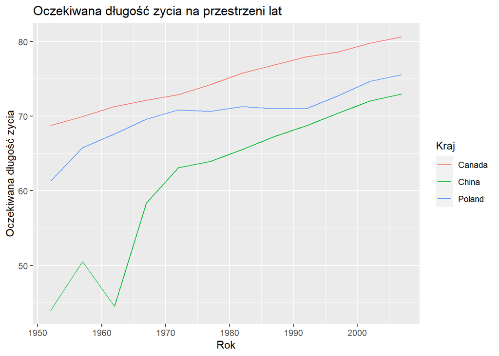

```r
ggplot(dane_long, aes(x = year, y = value, col = variable)) +
  labs(col = "Kraj", x = "Rok", y = "Oczekiwana długość zycia", title = "Oczekiwana długość zycia na przestrzeni lat") +
  geom_line()
```

## Ćw.2, Zadanie 7

Wyznaczyć podstawowe statystyki opisowe dot. wielkości populacji na różnych kontynentach w roku 2007. Pamiętaj o wykorzystaniu funkcji group_by() i summarize().

```r
gapminder %>%
  filter(year == 2007) %>%
  mutate(pop = pop/1000000) %>%
  group_by(continent) %>%
  summarize(śr_pop = mean(pop), suma_pop = sum(pop), odchyl_pop = sd(pop), min_pop = min(pop), max_pop = max(pop))
```

```
## # A tibble: 5 x 6
##   continent śr_pop suma_pop odchyl_pop min_pop max_pop
##   <fct>      <dbl>    <dbl>      <dbl>   <dbl>   <dbl>
## 1 Africa      17.9    930.        24.9   0.200   135.
## 2 Americas    36.0    899.        68.8   1.06    301.
## 3 Asia       116.    3812.       290.    0.709  1319.
## 4 Europe      19.5    586.        23.6   0.302    82.4
## 5 Oceania     12.3     24.5       11.5   4.12     20.4
```

# Część 2 - Analiza problemów badawczych.

## Zapoznanie się z danymi.

Wczytywanie danych.

```r
budzety2005 <- read.csv("budzety2005.csv", row.names=1)
```

Zerknięcie na dane

```r
glimpse(budzety2005)
```

```
## Rows: 30,003
## Columns: 66
## $ hhno           <int> 222670321, 112100821, 210021011, 200570421, 200010521, ~
## $ famno          <int> 1, 1, 1, 1, 1, 1, 1, 1, 1, 1, 1, 1, 1, 1, 1, 1, 1, 1, 1~
## $ persno         <int> 1, 1, 1, 1, 1, 1, 1, 1, 1, 1, 1, 1, 1, 1, 1, 1, 1, 1, 1~
## $ reltohoh       <chr> " head ", " head ", " head ", " head ", " head ", " hea~
## $ hoh            <int> 1, 1, 1, 1, 1, 1, 1, 1, 1, 1, 1, 1, 1, 1, 1, 1, 1, 1, 1~
## $ reltohof       <chr> "Head", "Head", "Head", "Head", "Head", "Head", "Head",~
## $ hofam          <int> 1, 1, 1, 1, 1, 1, 1, 1, 1, 1, 1, 1, 1, 1, 1, 1, 1, 1, 1~
## $ month_hh       <int> 3, 8, 10, 4, 5, 6, 6, 3, 5, 5, 8, 12, 7, 6, 2, 6, 10, 3~
## $ townsize       <chr> "villages", "town up to 19,999", "100,000 - 199,999", "~
## $ wojregion      <chr> "Malopolskie", "Lodzkie", "Dolnoslaskie", "Mazowieckie"~
## $ farmsize       <dbl> 0, 0, 0, 0, 0, 0, 0, 0, 0, 0, 0, 0, 0, 0, 0, 0, 0, 0, 0~
## $ farmnoeq       <dbl> 0, 0, 0, 0, 0, 0, 0, 0, 0, 0, 0, 0, 0, 0, 0, 0, 0, 0, 0~
## $ buildtype      <chr> "free standing", "multi-flat", "multi-flat", "multi-fla~
```

[output cut: 53 more lines]

Wybieram tylko interesujące mnie cechy.

```r
dane <- budzety2005 %>%
  select(pozycja = reltohoh, miesiac = month_hh,
         wielkosc_miasta = townsize, wojewodztwo = wojregion,
         zawod = mainincHH, wiek_glowy = ageofhead,
         wielkosc_farmy = farmsize, typ_mieszkania = buildtype,
         wielkosc_mieszkania = flatsize, wlasnosc_mieszkania = owntype,
         rachunki = bills, dochod_rodziny = totincGUS, wydatki_rodziny = totexpGUS,
         dochod = totinc_data, liczba_osob = numpHH, plec = sex, wiek = age,
         malzonek = married, edukacja = educ)
```

Poznanie wszystkich unikalnych wartości z kolumn kategorycznych oraz zamiana cechy wielkosc_miasta na factor.

```r
dane %>%
  select(where(is.character)) %>%
    lapply(unique)
```

```
## $pozycja
## [1] "head"                 "husband/wife"         "son/daughter"
## [4] "notrelated"           "otherrelative"        "mother/father(inlaw)"
##
## $wielkosc_miasta
## [1] "villages"          "town up to 19,999" "100,000 - 199,999"
## [4] "500,000 and over"  "200,000 - 499,999" "20,000  - 99,999"
##
## $wojewodztwo
##  [1] "Malopolskie"         "Lodzkie"             "Dolnoslaskie"
##  [4] "Mazowieckie"         "Zachodniopomorskie"  "Wielkopolskie"
##  [7] "Slaskie"             "Podkarpackie"        "Lubuskie"
## [10] "Warminsko-mazurskie" "Podlaskie"           "Lubelskie"
## [13] "Pomorskie"           "Kujawsko-pomorskie"  "Swietokrzyskie"
## [16] "Opolskie"
##
## $zawod
##  [1] "disability pens."
##  [2] "retirement pens."
##  [3] "employee, non-manual"
##  [4] "employee, manual"
##  [5] "nonfarm selfempl."
##  [6] "unemployment benefit"
##  [7] "farmer"
##  [8] "gifts, alimony payments from other people, other income"
##  [9] "other social assistance"
## [10] "other"
## [11] "from rent of house(flat), garage"
##
## $typ_mieszkania
## [1] "free standing" "multi-flat"    "terrace/twin"  "other"
##
## $wlasnosc_mieszkania
## [1] "owned outright"         "other rented."          "Social rented or owned"
## [4] "other"                  "owned with mortgage"
##
## $plec
## [1] "male"    "female "
##
## $edukacja
## [1] "primary"             "high school"         "university"
## [4] "vocational training" "no education"        "n/a"
```

```r
dane$wielkosc_miasta <- factor(dane$wielkosc_miasta)
levels(dane$wielkosc_miasta) <- c('village', '<20k', '20k-100k', '100k-200k', '200k-500k', '>500k')
```

## Czy wielkość miasta, w którym mieszkamy wpływa na naszą edukację?

Biorę pod uwagę tylko osoby, które już mogły ukończyć studia, czyli w wieku 25 lat i więcej.

Tutaj dodatkowo zainteresowałem się tym jaki jest średni wiek osób z daną edukacją.

```r
d3 <- dane %>%
  filter(wiek>25) %>%
  group_by(edukacja) %>%
  summarize(n = n(), sr_wiek = mean(wiek)) %>%
  mutate(procent = round((n/(sum(n))),2)) %>%
  select(-n)
d3
```

```
## # A tibble: 5 x 3
##   edukacja            sr_wiek procent
##   <chr>                 <dbl>   <dbl>
## 1 high school            50.6    0.32
## 2 no education           74.6    0.01
## 3 primary                62.0    0.24
## 4 university             46.6    0.14
## 5 vocational training    48.1    0.28
```

Jak widać, im osoby są starsze mają niższe wykształcenie. Może być to spowodowane tym, że w wcześniejszych latach dostęp do uniwersytetów był bardziej ograniczony.

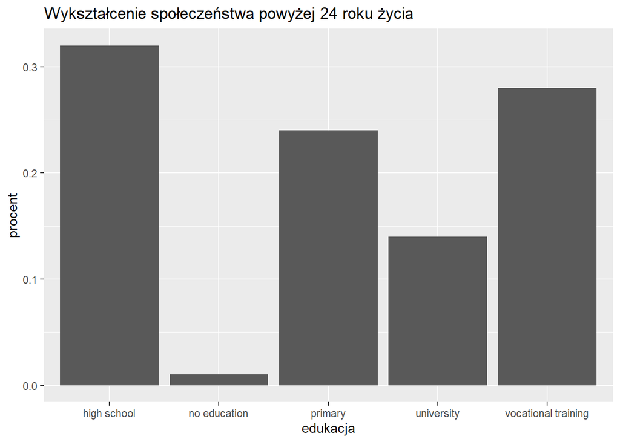

```r
d3 %>%
  ggplot(aes(x=edukacja, y=procent)) +
  geom_bar(stat = "identity") +
  ggtitle("Wykształcenie społeczeństwa powyżej 24 roku życia")
```

```r
d1 <- dane %>%
  filter(wiek>25) %>%
  select(wielkosc_miasta, edukacja) %>%
  group_by(wielkosc_miasta, edukacja) %>%
  summarize(n = n())
```

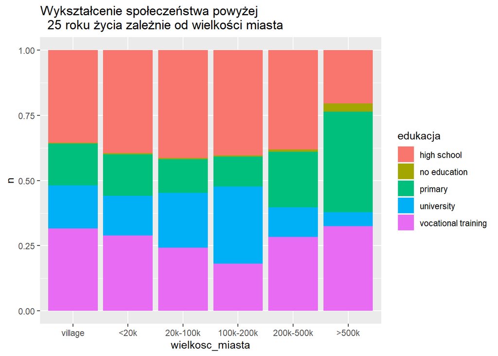

```r
d1 %>%
  ggplot(aes(fill=edukacja, x=wielkosc_miasta, y=n)) +
  geom_bar(position="fill", stat="identity") +
  ggtitle("Wykształcenie społeczeństwa powyżej
  25 roku życia zależnie od wielkości miasta")
```

```r
d2 <- d1 %>%
  group_by(wielkosc_miasta) %>%
  mutate(pr = round(n/sum(n),2)) %>%
  select(-n)
```

```r
d2 %>%
  top_n(3,pr) %>%
  arrange(wielkosc_miasta, desc(pr))
```

```
## # A tibble: 18 x 3
## # Groups:   wielkosc_miasta [6]
##    wielkosc_miasta edukacja               pr
##    <fct>           <chr>               <dbl>
##  1 village         high school          0.35
##  2 village         vocational training  0.32
##  3 village         university           0.17
##  4 <20k            high school          0.39
##  5 <20k            vocational training  0.29
##  6 <20k            primary              0.16
##  7 20k-100k        high school          0.41
##  8 20k-100k        vocational training  0.24
##  9 20k-100k        university           0.21
## 10 100k-200k       high school          0.4
## 11 100k-200k       university           0.3
## 12 100k-200k       vocational training  0.18
## 13 200k-500k       high school          0.38
## 14 200k-500k       vocational training  0.28
## 15 200k-500k       primary              0.21
## 16 >500k           primary              0.39
## 17 >500k           vocational training  0.32
## 18 >500k           high school          0.2
```

Na wykresie i w tabeli powyżej widać, że we wsi oraz w miastach mniejszych niż 500 000 najczęściej wybieranym poziomem edukacji jest szkoła średnia, a w miastach większych niż 500 000 mieszkańców szkoła podstawowa.

```r
d2 %>%
  top_n(-2,pr)
```

```
## # A tibble: 12 x 3
## # Groups:   wielkosc_miasta [6]
##    wielkosc_miasta edukacja        pr
##    <fct>           <chr>        <dbl>
##  1 village         no education  0
##  2 village         primary       0.16
##  3 <20k            no education  0.01
##  4 <20k            university    0.15
##  5 20k-100k        no education  0
##  6 20k-100k        primary       0.13
##  7 100k-200k       no education  0
##  8 100k-200k       primary       0.12
##  9 200k-500k       no education  0.01
## 10 200k-500k       university    0.11
## 11 >500k           no education  0.03
## 12 >500k           university    0.05
```

Z tabeli powyżej można dowiedzieć się, że dla każdego poziomu miasta najmniej osób nie ma żadnej edukacji. Co ciekawe w dużych miastach (powyżej 200 000) kolejno najrzadziej osoby wybierają się na uczelnie wyższą, a na wsi najrzadziej kończą edukację na szkole podstawowej.

## Czy wielkość miasta, w którym mieszkamy wpływa na to, że osoby powyzej 19 roku zycia mieszkaja z rodzicami? Jaki jest średni wiek osób mieszkających z rodzicami?

```r
d4 <- dane %>%
  filter(pozycja == "son/daughter" , wiek > 19) %>%
  select(wielkosc_miasta, wiek, dochod, edukacja, plec)
d4 %>%
  group_by(plec) %>%
  summarize(n = n())
```

```
## # A tibble: 2 x 2
##   plec          n
##   <chr>     <int>
## 1 "female "  1214
## 2 "male"     1646
```

W Polsce liczba mężczyzn mieszkających z rodzicami jest większa o 36% od liczby kobiet mieszkających z rodzicami.

```r
dane %>%
  filter(wiek > 19) %>%
  group_by(pozycja, wielkosc_miasta) %>%
  summarize(n = n(), sr_wieku = mean(wiek)) %>%
  group_by(wielkosc_miasta) %>%
  mutate(procent = round(n/sum(n),2)) %>%
  arrange(desc(wielkosc_miasta)) %>%
  filter(pozycja == "son/daughter") %>%
  select(-n)
```

```
## # A tibble: 6 x 4
## # Groups:   wielkosc_miasta [6]
##   pozycja      wielkosc_miasta sr_wieku procent
##   <chr>        <fct>              <dbl>   <dbl>
## 1 son/daughter >500k               28.6    0.13
## 2 son/daughter 200k-500k           27.5    0.11
## 3 son/daughter 100k-200k           27.0    0.1
## 4 son/daughter 20k-100k            27.4    0.12
## 5 son/daughter <20k                26.4    0.12
## 6 son/daughter village             27.5    0.11
```

Jak widać w kolumnie procent pokazane jest ile procent społeczeństwa danej wielkości miasta zajmują osoby w wieku większym niż 19 lat mieszkające z rodzicami. Jest to około 12 procent dla każdego z przedziałów ludności miast. Średnia wieku dla tych osób dla każdej z wielkości miasta jest równa około 27 lat.

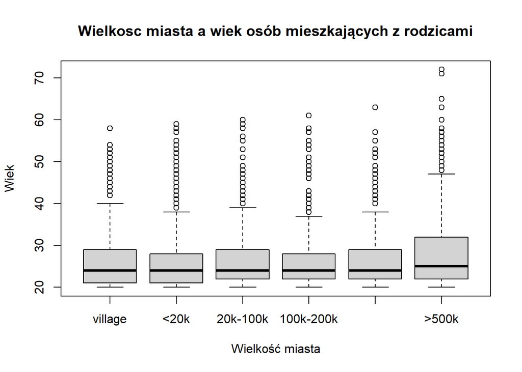

```r
d <- dane %>%
  filter(wiek > 19, pozycja == "son/daughter")
boxplot(d$wiek~d$wielkosc_miasta,
        main="Wielkosc miasta a wiek osób mieszkających z rodzicami",
        xlab="Wielkość miasta",
        ylab="Wiek",)
```

## Czy dochód ma jakieś znaczenie przy mieszkaniu z rodzicami? Czy im mniejszy dochód tym więcej osób mieszka z rodzicami?

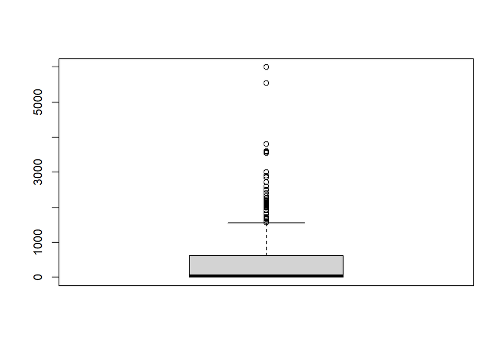

```r
boxplot(d4$dochod)
```

Z tego wykresu pudełkowego wiem, że bardzo dużo osób ma dochód równy 0 zł.

```r
l0 <- sum(d4$dochod == 0)
round(sum(d4$dochod == 0) / (sum(d4$dochod != 0) + sum(d4$dochod == 0)) * 100,2)
```

```
## [1] 46.89
```

```r
l1 <- sum(d4$dochod >= 3000)
round(sum(d4$dochod >= 3000) / (sum(d4$dochod > 3000) + sum(d4$dochod <= 3000)) * 100,2)
```

```
## [1] 0.24
```

Dochód równy 0 zł posiada 1341 osób. Jest to aż 47% osób mieszkających z rodzicami. Dochód większy niż 3000 zł posiada niecały 1% badanych.

Usuwam wartości równe 0 zł i większe lub równe 3000 zł.

```r
d5 <- d4 %>%
  filter(dochod != 0, dochod < 3000)
summary(d5$dochod)
```

```
##     Min.  1st Qu.   Median     Mean  3rd Qu.     Max.
##    1.667  350.000  600.000  640.546  843.715 2900.000
```

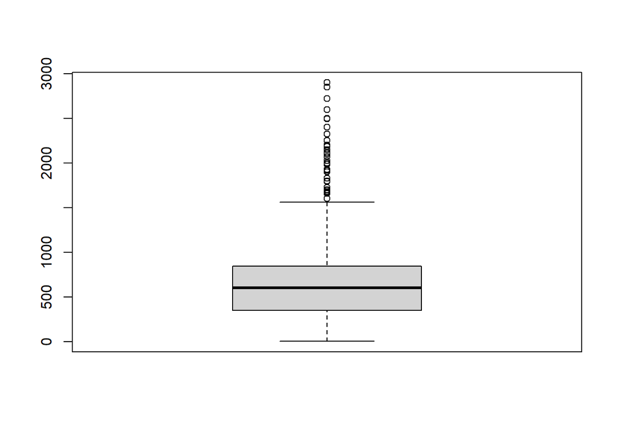

```r
boxplot(d5$dochod)
```

Podzielę te dane na 4 grupy.

```r
range(d5$dochod)
```

```
## [1]    1.666667 2900.000000
```

```r
(max(d5$dochod) - min(d5$dochod))/4
```

```
## [1] 724.5833
```

Dodałem kolumnę z grupami, do których należą osoby mające określony dochód.

```r
d6 <- d5 %>%
  mutate(grupa = if_else(between(dochod,1,725), "1-725", if_else(between(dochod,726,1450),"726-1450", if_else(between(dochod,1451,2175),"1451-2175", "2176-2900"))))
```

```r
d7 <- d6 %>%
  group_by(grupa) %>%
  summarize(n = n()) %>%
  add_row(grupa = c("0", "2900+"), n = c(l0,l1))
d7$grupa <- factor(d7$grupa, levels = c("0","1-725","726-1450", "1451-2175","2176-2900","2900+"))
d7 <- d7 %>%
  arrange(grupa)
d7
```

```
## # A tibble: 6 x 2
##   grupa         n
##   <fct>     <int>
## 1 0          1341
## 2 1-725       968
## 3 726-1450    467
## 4 1451-2175    65
## 5 2176-2900    12
## 6 2900+         7
```

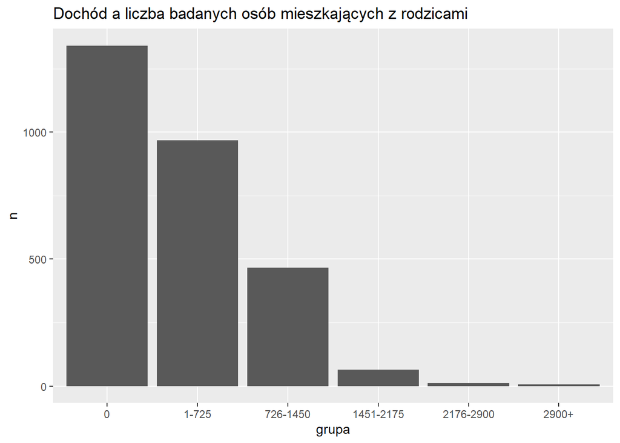

```r
d7 %>%
  ggplot(aes(x=grupa, y=n)) +
  geom_bar(stat="identity") +
  ggtitle("Dochód a liczba badanych osób mieszkających z rodzicami")
```

## Czy typ mieszkania wpływają na wydatki?

Wybieram dane i usuwam te wiersze, w których wielkość mieszkania jest równa 0.

```r
dane3 <- dane %>%
  filter(pozycja == "head", wielkosc_mieszkania != 0) %>%
  select(wielkosc_miasta, wojewodztwo, typ_mieszkania,wielkosc_mieszkania, liczba_osob, wydatki_rodziny)
```

```r
dane3 %>%
  select(typ_mieszkania, wielkosc_mieszkania) %>%
  group_by(typ_mieszkania) %>%
  summarize(srednia = mean(wielkosc_mieszkania))
```

```
## # A tibble: 4 x 2
##   typ_mieszkania srednia
##   <chr>            <dbl>
## 1 free standing     86.1
## 2 multi-flat        48.5
## 3 other             47.0
## 4 terrace/twin      85.6
```

Tabela powyżej przedstawia średnią wielkość poszczególnych typów lokali mieszkalnych w Polsce.

```r
dane3 %>%
  select(typ_mieszkania, wielkosc_mieszkania, wydatki_rodziny) %>%
  group_by(typ_mieszkania) %>%
  summarize(sr_wydatki = mean(wydatki_rodziny))
```

```
## # A tibble: 4 x 2
##   typ_mieszkania sr_wydatki
##   <chr>               <dbl>
## 1 free standing       1811.
## 2 multi-flat          1867.
## 3 other               1416.
## 4 terrace/twin        2063.
```

## Jakie są najczęściej wybierane lokale mieszkalne dla różnych wielkości miast oraz w ile osób ludzie najczęściej mieszkają.

```r
dane3 %>%
  group_by(wielkosc_miasta, typ_mieszkania) %>%
  summarize(n = n()) %>%
  group_by(wielkosc_miasta) %>%
  mutate(procent = round(n/sum(n),2)) %>%
  top_n(3,n) %>%
  arrange(wielkosc_miasta, desc(n))
```

```
## # A tibble: 18 x 4
## # Groups:   wielkosc_miasta [6]
##    wielkosc_miasta typ_mieszkania     n procent
##    <fct>           <chr>          <int>   <dbl>
##  1 village         multi-flat       867    0.82
##  2 village         free standing    156    0.15
##  3 village         terrace/twin      28    0.03
##  4 <20k            multi-flat      2054    0.79
##  5 <20k            free standing    400    0.15
##  6 <20k            terrace/twin     131    0.05
##  7 20k-100k        multi-flat      1298    0.89
##  8 20k-100k        free standing     95    0.06
##  9 20k-100k        terrace/twin      67    0.05
## 10 100k-200k       multi-flat      1815    0.91
## 11 100k-200k       free standing     98    0.05
## 12 100k-200k       terrace/twin      75    0.04
## 13 200k-500k       multi-flat       982    0.67
## 14 200k-500k       free standing    390    0.27
## 15 200k-500k       terrace/twin      88    0.06
## 16 >500k           free standing   3158    0.76
## 17 >500k           multi-flat       701    0.17
## 18 >500k           terrace/twin     295    0.07
```

W tabeli powyżej ukazane jest, że najczęściej wybieranym lokalem mieszkalnym jest mieszkanie, jedynie w miastach powyżej 500 000 mieszkańców najwięcej rodzin mieszka w domu wolnostojącym.

```r
dane3 %>%
  group_by(wielkosc_miasta, liczba_osob) %>%
  summarize(n = sum(liczba_osob)) %>%
  top_n(3,n) %>%
  arrange(wielkosc_miasta, desc(n))
```

```
## # A tibble: 18 x 3
## # Groups:   wielkosc_miasta [6]
##    wielkosc_miasta liczba_osob     n
##    <fct>                 <int> <int>
##  1 village                   2   744
##  2 village                   3   609
##  3 village                   4   404
##  4 <20k                      2  1860
##  5 <20k                      3  1590
##  6 <20k                      4  1288
##  7 20k-100k                  2  1002
##  8 20k-100k                  3   882
##  9 20k-100k                  4   584
## 10 100k-200k                 2  1296
## 11 100k-200k                 3  1149
## 12 100k-200k                 1   760
## 13 200k-500k                 2   990
## 14 200k-500k                 3   846
## 15 200k-500k                 4   780
## 16 >500k                     2  2706
## 17 >500k                     4  2636
## 18 >500k                     3  2307
```

W tabeli powyżej ukazane jest, że dla każdej wielkości miasta najbardziej popularne jest mieszkanie w 2 osoby. Wielkość miasta, w jakim mieszkamy nie wpływa na wielkość rodziny.